# Details

Name: Shahar Raz

Competition: Titanic - Kaggle

date 17.11.2020

Link: https://www.kaggle.com/shaharaz/ml-2021a-1regression

# Data Description

pclass: A proxy for socio-economic status (SES) 1st = Upper 2nd = Middle 3rd = Lower

age: Age is fractional if less than 1. If the age is estimated, is it in the form of xx.5

sibsp: The dataset defines family relations in this way... Sibling = brother, sister, stepbrother, stepsister Spouse = husband, wife (mistresses and fiancés were ignored)

parch: The dataset defines family relations in this way... Parent = mother, father Child = daughter, son, stepdaughter, stepson Some children travelled only with a nanny, therefore parch=0 for them.

## Data Frames NAMING

test_df -> test_data -> final_test

titanic_df -> train_data -> final_train

final_train -> X_train, X_test, y_train, y_test

```python
#    list all files under the input directory
import os
for dirname, _, filenames in os.walk('/kaggle/input'):
    for filename in filenames:
        print(os.path.join(dirname, filename))
```

## 1. Import Data & Python Packages

```python
# Imports

# pandas
import pandas as pd
from pandas import Series,DataFrame

# numpy, matplotlib
import numpy as np
import matplotlib.pyplot as plt

#seaborn settings:
import seaborn as sns
sns.set(style="white") #white background style for seaborn plots
sns.set(style="whitegrid", color_codes=True)
%matplotlib inline

# make sure that the plot doesn't take the entire screen



# machine learning
from sklearn.linear_model import LogisticRegression
```

```python
# # Kaggle Import
# titanic_df = pd.read_csv("train.csv") # training with y! titanic_df -> train_data -> final_train
# test_df    = pd.read_csv("test.csv") # test without y!   test_df -> test_data -> final_test

# # preview the data
# titanic_df.head()
```

```python
# get titanic & test csv files as a DataFrame

# # Kaggle Import
# titanic_df = pd.read_csv("/kaggle/input/titanic/train.csv") # training with y
# test_df    = pd.read_csv("/kaggle/input/titanic/test.csv") # test with y

# Colab Import
titanic_df = pd.read_csv("train.csv") # training with y! titanic_df -> train_data -> final_train
test_df    = pd.read_csv("test.csv") # test without y!   test_df -> test_data -> final_test

# preview the data
titanic_df.head()
```

|  | PassengerId | Survived | Pclass | Name | Sex | Age | SibSp | Parch | Ticket | Fare | Cabin | Embarked |
| --- | --- | --- | --- | --- | --- | --- | --- | --- | --- | --- | --- | --- |
| 0 | 1 | 0 | 3 | Braund, Mr. Owen Harris | male | 22.0 | 1 | 0 | A/5 21171 | 7.2500 | NaN | S |
| 1 | 2 | 1 | 1 | Cumings, Mrs. John Bradley (Florence Briggs Th... | female | 38.0 | 1 | 0 | PC 17599 | 71.2833 | C85 | C |
| 2 | 3 | 1 | 3 | Heikkinen, Miss. Laina | female | 26.0 | 0 | 0 | STON/O2. 3101282 | 7.9250 | NaN | S |
| 3 | 4 | 1 | 1 | Futrelle, Mrs. Jacques Heath (Lily May Peel) | female | 35.0 | 1 | 0 | 113803 | 53.1000 | C123 | S |
| 4 | 5 | 0 | 3 | Allen, Mr. William Henry | male | 35.0 | 0 | 0 | 373450 | 8.0500 | NaN | S |

```python
test_df.head()
```

|  | PassengerId | Pclass | Name | Sex | Age | SibSp | Parch | Ticket | Fare | Cabin | Embarked |
| --- | --- | --- | --- | --- | --- | --- | --- | --- | --- | --- | --- |
| 0 | 892 | 3 | Kelly, Mr. James | male | 34.5 | 0 | 0 | 330911 | 7.8292 | NaN | Q |
| 1 | 893 | 3 | Wilkes, Mrs. James (Ellen Needs) | female | 47.0 | 1 | 0 | 363272 | 7.0000 | NaN | S |
| 2 | 894 | 2 | Myles, Mr. Thomas Francis | male | 62.0 | 0 | 0 | 240276 | 9.6875 | NaN | Q |
| 3 | 895 | 3 | Wirz, Mr. Albert | male | 27.0 | 0 | 0 | 315154 | 8.6625 | NaN | S |
| 4 | 896 | 3 | Hirvonen, Mrs. Alexander (Helga E Lindqvist) | female | 22.0 | 1 | 1 | 3101298 | 12.2875 | NaN | S |

Embarked (the place the passangers boarded the boat) C - Cherbourg , S - Southhampton , Q - Queenstown

## 2. Data Quality & Missing Value Assessment

in-order to use all the rows, we'll need to insert values instead of the Not Availble values:

(we can't have missing values inside our data)

So, we would like to enter a **natural** values instead of the the missing values

#### Note: data already splitted to train & test

```python
# # drop unnecessary columns, these columns won't be useful in analysis and prediction
titanic_df = titanic_df.drop(['PassengerId','Name','Ticket'], axis=1)
# test_df    = test_df.drop(['PassengerId','Name','Ticket'], axis=1) # not dropping, since pID needed for final prediction
```

```python
# see all features
# null features count [981-(non-null)]
# data type of each feature
# Numeration of type in dataset

print('Training Set:\n')
titanic_df.info()
print("\n\n___-___-___-_______________________________-___-___-___\n\n")
print('Test Set:\n')
test_df.info()
```

```
Training Set:

<class 'pandas.core.frame.DataFrame'>
RangeIndex: 891 entries, 0 to 890
Data columns (total 9 columns):
 #   Column    Non-Null Count  Dtype
---  ------    --------------  -----
 0   Survived  891 non-null    int64
 1   Pclass    891 non-null    int64
 2   Sex       891 non-null    object
 3   Age       714 non-null    float64
 4   SibSp     891 non-null    int64
 5   Parch     891 non-null    int64
 6   Fare      891 non-null    float64
 7   Cabin     204 non-null    object
 8   Embarked  889 non-null    object
dtypes: float64(2), int64(4), object(3)
memory usage: 62.8+ KB


___-___-___-_______________________________-___-___-___


Test Set:

<class 'pandas.core.frame.DataFrame'>
RangeIndex: 418 entries, 0 to 417
Data columns (total 11 columns):
 #   Column       Non-Null Count  Dtype
---  ------       --------------  -----
 0   PassengerId  418 non-null    int64
 1   Pclass       418 non-null    int64
 2   Name         418 non-null    object
 3   Sex          418 non-null    object
 4   Age          332 non-null    float64
 5   SibSp        418 non-null    int64
 6   Parch        418 non-null    int64
 7   Ticket       418 non-null    object
 8   Fare         417 non-null    float64
 9   Cabin        91 non-null     object
 10  Embarked     418 non-null    object
dtypes: float64(2), int64(4), object(5)
memory usage: 36.0+ KB
```

## NOTE! test set has no validation (True values)

### 2.1 Age - Missing Values

```python
print('num of missing age values:' ,sum(pd.isnull(titanic_df['Age'])))
```

```
num of missing age values: 177
```

```python
# proportion of "Age" missing
precOfAgeMissing= round(17700/(len(titanic_df["Survived"])),4)
print('which are: ' , precOfAgeMissing , '% of the data')
```

```
which are:  19.8653 % of the data
```

#### 2.1.1 find Natural Values - Age - Missing Values

~20% of entries for passenger age are missing. Let's see what the 'Age' variable looks like in general.

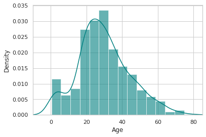

```python
plot_age_Survivial = titanic_df["Age"].hist(bins=15, density=True, stacked=True, color='teal', alpha=0.6)
titanic_df["Age"].plot(kind='density', color='teal')
plot_age_Survivial.set(xlabel='Age')
plt.xlim(-10,85)
plt.show()
```

Since "Age" is (right) skewed, using the mean might give us biased results by filling in ages that are older than desired. To deal with this, we'll use the median to impute the missing values.

```python
# median age is 28 (as compared to mean which is ~30)
titanic_df["Age"].median(skipna=True)


# in the end of section 2, we'll see how we insert these values into the set.
# train_data = titanic_df
# train_data["Age"].fillna(28, inplace=True)
```

```
28.0
```

### 2.2 Cabin - Missing Values

```python
# proportion of "cabin" missing

precOfCabinMissing = round(68700/len(titanic_df["Survived"]),4)
print('which are: ' , precOfCabinMissing , '% of the data')
```

```
which are:  77.1044 % of the data
```

77% of records are missing, which means that imputing information and using this variable for prediction is probably not wise. We'll ignore this variable in our model.

### 2.3 Embarked(Boarded) - Missing Values

```python
# proportion of "Embarked" missing
precOfEmbarkedMissing = round(200/len(titanic_df["Survived"]),4)

print('which are: ' , precOfEmbarkedMissing , '% of the data')
```

```
which are:  0.2245 % of the data
```

There are only 2 missing values for "Embarked", so we can just impute with the port where most people boarded.

#### 2.3.1 find Natural Values - Embarked - Missing Values

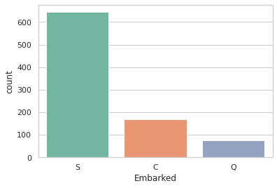

```python
sns.countplot(x='Embarked',data=titanic_df,palette='Set2')
plt.show()
```

By far the most passengers boarded in Southhampton, so we'll impute those 2 NaN's w/ "S".

### 2.4 Fare - Missing Values

Fare is a missing value at the test set

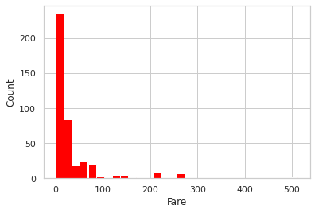

```
14.4542
```

```
35.6271884892086
```

```python
ax2 = test_df["Fare"].hist(bins=30, color='red', alpha=1)
ax2.set(xlabel='Fare', ylabel='Count')
plt.show()
display(test_df["Fare"].median(skipna=True) , test_df["Fare"].mean() )
```

### 2.5 Final Adjustments to Data (Train & Test)

Based on my assessment of the missing values in the dataset, I'll make the following changes to the data:

```python
display(titanic_df.isnull().sum(), test_df.isnull().sum())
```

```
Survived      0
Pclass        0
Sex           0
Age         177
SibSp         0
Parch         0
Fare          0
Cabin       687
Embarked      2
dtype: int64
```

```
PassengerId      0
Pclass           0
Name             0
Sex              0
Age             86
SibSp            0
Parch            0
Ticket           0
Fare             1
Cabin          327
Embarked         0
dtype: int64
```

```python
# Train Transformation
train_data = titanic_df.copy()
train_data["Age"].fillna(28, inplace=True) # median age is 28
train_data["Embarked"].fillna("S", inplace=True) # most passengers boarded in Southhampton
train_data.drop('Cabin', axis=1, inplace=True) # 77% of records are missing, we'll ignote this var

#______________________ FOR Test sample:
test_data = test_df.copy()
test_data["Age"].fillna(28, inplace=True) # median age is 28
test_data["Embarked"].fillna("S", inplace=True) # most passengers boarded in Southhampton
test_data.drop('Cabin', axis=1, inplace=True) # 77% of records are missing, we'll ignote this var
```

```python
display(train_data.isnull().sum(), test_data.isnull().sum())
```

```
Survived    0
Pclass      0
Sex         0
Age         0
SibSp       0
Parch       0
Fare        0
Embarked    0
dtype: int64
```

```
PassengerId    0
Pclass         0
Name           0
Sex            0
Age            0
SibSp          0
Parch          0
Ticket         0
Fare           1
Embarked       0
dtype: int64
```

### 2.5.1 Additional Variables

a. *TRAVEL ALONE* :According to the Kaggle data dictionary, both SibSp and Parch relate to traveling with family. For simplicity's sake (and to account for possible multicollinearity), I'll combine the effect of these variables into one categorical predictor: whether or not that individual was traveling alone.

```python
## Create categorical variable for traveling alone
train_data['TravelAlone']=np.where((train_data["SibSp"]+train_data["Parch"])>0, 0, 1)
train_data.drop('SibSp', axis=1, inplace=True)
train_data.drop('Parch', axis=1, inplace=True)

#______________________ FOR Test sample:
test_data['TravelAlone']=np.where((test_data["SibSp"]+test_data["Parch"])>0, 0, 1)
test_data.drop('SibSp', axis=1, inplace=True)
test_data.drop('Parch', axis=1, inplace=True)
```

b. *CATEGORICAL* Pclass,Sex,Embarked [Like OneHotEncoding]

create categorical variables for Passenger Class ("Pclass"), Gender ("Sex"), and Port Embarked ("Embarked").

```python
# create categorical variables and drop some variables
training=pd.get_dummies(train_data, columns=["Pclass","Embarked","Sex"])
training.drop('Sex_female', axis=1, inplace=True)
# training.drop('PassengerId', axis=1, inplace=True)
# training.drop('Name', axis=1, inplace=True)
# training.drop('Ticket', axis=1, inplace=True)

final_train = training
final_train.head()


#______________________ FOR Test sample:
testing=pd.get_dummies(test_data, columns=["Pclass","Embarked","Sex"])
testing.drop('Sex_female', axis=1, inplace=True)
# testing.drop('PassengerId', axis=1, inplace=True)
# testing.drop('Name', axis=1, inplace=True)
# testing.drop('Ticket', axis=1, inplace=True)

final_test = testing
final_test.head()



# Come Back here and fix me
```

|  | PassengerId | Name | Age | Ticket | Fare | TravelAlone | Pclass_1 | Pclass_2 | Pclass_3 | Embarked_C | Embarked_Q | Embarked_S | Sex_male |
| --- | --- | --- | --- | --- | --- | --- | --- | --- | --- | --- | --- | --- | --- |
| 0 | 892 | Kelly, Mr. James | 34.5 | 330911 | 7.8292 | 1 | 0 | 0 | 1 | 0 | 1 | 0 | 1 |
| 1 | 893 | Wilkes, Mrs. James (Ellen Needs) | 47.0 | 363272 | 7.0000 | 0 | 0 | 0 | 1 | 0 | 0 | 1 | 0 |
| 2 | 894 | Myles, Mr. Thomas Francis | 62.0 | 240276 | 9.6875 | 1 | 0 | 1 | 0 | 0 | 1 | 0 | 1 |
| 3 | 895 | Wirz, Mr. Albert | 27.0 | 315154 | 8.6625 | 1 | 0 | 0 | 1 | 0 | 0 | 1 | 1 |
| 4 | 896 | Hirvonen, Mrs. Alexander (Helga E Lindqvist) | 22.0 | 3101298 | 12.2875 | 0 | 0 | 0 | 1 | 0 | 0 | 1 | 0 |

```python
# # check again for null values
display(final_train.isnull().sum(), final_test.isnull().sum())
```

```
Survived       0
Age            0
Fare           0
TravelAlone    0
Pclass_1       0
Pclass_2       0
Pclass_3       0
Embarked_C     0
Embarked_Q     0
Embarked_S     0
Sex_male       0
dtype: int64
```

```
PassengerId    0
Name           0
Age            0
Ticket         0
Fare           1
TravelAlone    0
Pclass_1       0
Pclass_2       0
Pclass_3       0
Embarked_C     0
Embarked_Q     0
Embarked_S     0
Sex_male       0
dtype: int64
```

# 3. Exploratory Data Analysis

Failed attempt to plot multiple plots at once : (ref from Prac2)

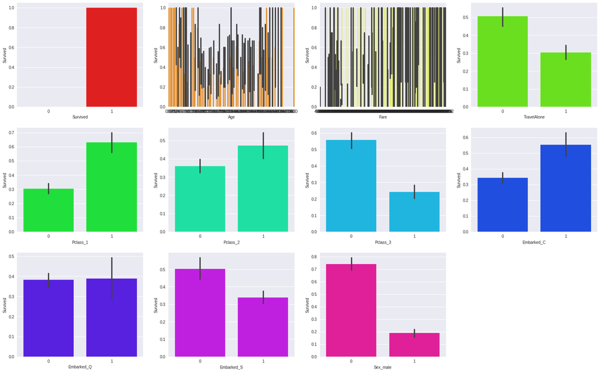

```python
import math
# plot the connection between 2 features
def plot_connection_between_2_features(df, feature_1_name, feature_2_name):
    df.plot.scatter(x=feature_1_name, y=feature_2_name, title=f'{feature_1_name} by {feature_2_name}')

# get color map
def get_cmap(n, name='hsv'):
    return plt.cm.get_cmap(name, n)

# plot target values by each feature
def plot_target_values_by_each_feature(df, target_column_name):
    nrows = math.ceil(math.sqrt(len(df.columns)+1))
    ncols = math.ceil((len(df.columns)+1)/nrows)
    plt.style.use('seaborn')
    fig, axes = plt.subplots(nrows, ncols)
    plt.subplots_adjust(top=3, bottom=0, left=0, right=2.5)
    colors = get_cmap(len(df.columns))

    counter = 0
    for i in range(len(df.columns)-1):
        sns.barplot(x = df.columns[i], y = target_column_name, data=df, color=colors(i), ax=axes[i//nrows, i%nrows])
        axes[i//nrows, i%nrows].tick_params(axis='both', labelsize=10)
        axes[i//nrows, i%nrows].xaxis.label.set_size(10)
        axes[i//nrows, i%nrows].yaxis.label.set_size(10)
        axes[i//nrows, i%nrows].title.set_fontsize(10)

    for i in range(len(df.columns)-1, nrows*ncols):
        fig.delaxes(axes.flatten()[i])


plot_target_values_by_each_feature(final_train, 'Survived')

#Tried to make it these graphs like the one in section 3.5, unsuccesfuly
# tried to Fix these graphs using these survive vs not survive based on other factors (replacments for row 21)
# 1.    sns.barplot('TravelAlone', 'Survived', data=final_train, color="mediumturquoise")
# 2.    df.plot(kind='bar', x=df.columns[i], y=target_column_name, title=f'{df.columns[i]} by {target_column_name}', ax=axes[i//nrows, i%nrows], color=colors(i))
# 3.    sns.barplot(x = df.columns[i], y = target_column_name, data=df, color=colors(i))
# 4.    df.plot(kind='scatter', x=df.columns[i], y=target_column_name, title=f'{df.columns[i]} by {target_column_name}', ax=axes[i//nrows, i%nrows], color=colors(i))
```

```python
final_train.head()
```

[output not shown]

### look for potential correlations using heat-map

```python
import matplotlib.pyplot as plt

# define plt settings
plt.rcParams["font.size"] = 18
plt.rcParams["axes.labelsize"] = 20
plt.rcParams["xtick.labelsize"] = 20
plt.rcParams["ytick.labelsize"] = 20
plt.rcParams["legend.fontsize"] = 20
plt.rcParams["figure.figsize"] = (20,10)
```

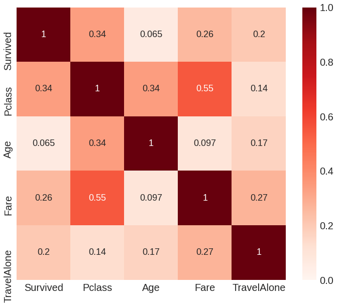

```python
# show absolute correlation between features in a heatmap
plt.figure(figsize=(12,10))
cor = np.abs(train_data.corr())
sns.heatmap(cor, annot=True, cmap=plt.cm.Reds, vmin=0, vmax=1,)
plt.show()
```

obviesly, corelation with boolean variable isn't high, but we can still see that Pclass , Farre & LonlyTravelers has better correlation than the other

## 3.1 Exploration of Age

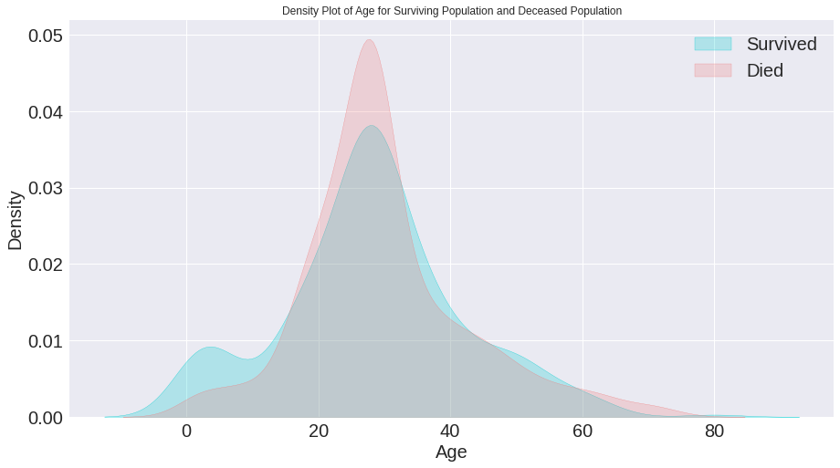

```python
plt.figure(figsize=(15,8))
sns.kdeplot(final_train["Age"][final_train.Survived == 1], color="darkturquoise", shade=True)
sns.kdeplot(final_train["Age"][final_train.Survived == 0], color="lightcoral", shade=True)
plt.legend(['Survived', 'Died'])
plt.title('Density Plot of Age for Surviving Population and Deceased Population')
plt.show()
```

The age distribution for survivors and deceased is actually very similar. One notable difference is that, of the survivors, a larger proportion were children. The passengers evidently made an attempt to save children by giving them a place on the life rafts.

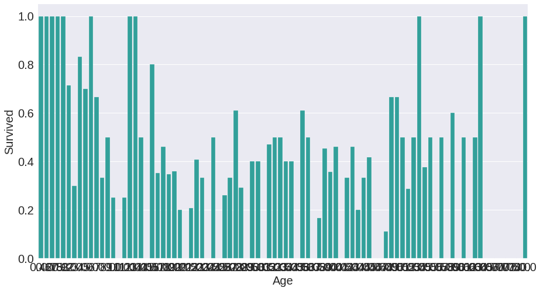

```python
plt.figure(figsize=(15,8))
avg_survival_byage = final_train[["Age", "Survived"]].groupby(['Age'],as_index=False).mean()
g = sns.barplot(x='Age', y='Survived', data=avg_survival_byage, color="LightSeaGreen")
```

Considering the survival rate of passengers under 16, I'll also include another categorical variable in my dataset: "Minor"

```python
# add to training set:
final_train['IsMinor']=np.where(train_data['Age']<=16, 1, 0)

# # add to test set:
final_test['IsMinor']=np.where(test_data['Age']<=16, 1, 0)
```

## 3.2 Exploration of Fare

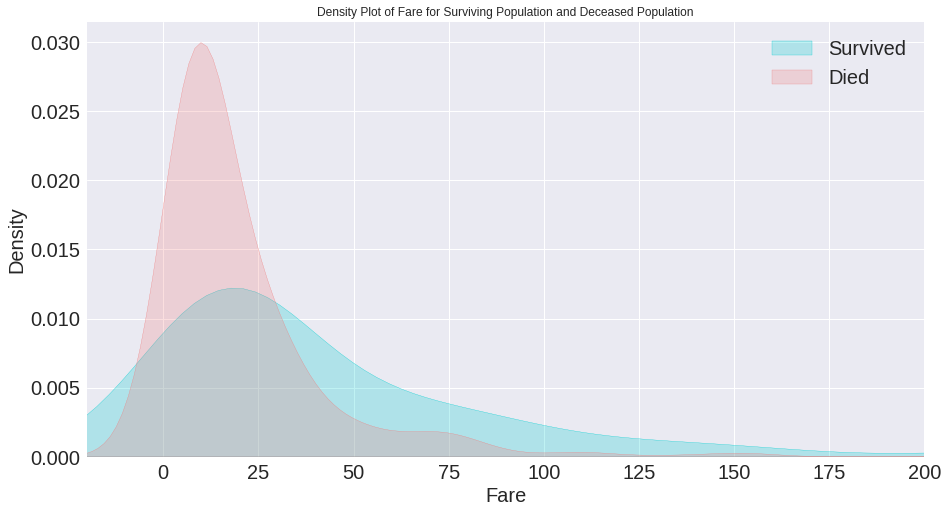

```python
plt.figure(figsize=(15,8))
sns.kdeplot(final_train["Fare"][final_train.Survived == 1], color="darkturquoise", shade=True)
sns.kdeplot(final_train["Fare"][final_train.Survived == 0], color="lightcoral", shade=True)
plt.legend(['Survived', 'Died'])
plt.title('Density Plot of Fare for Surviving Population and Deceased Population')
# limit x axis to zoom on most information. there are a few outliers in fare.
plt.xlim(-20,200)
plt.show()
```

As the distributions are clearly different for the fares of survivors vs. deceased, it's likely that this would be a significant predictor in our final model. Passengers who paid lower fare appear to have been less likely to survive. This is probably strongly correlated with Passenger Class, which we'll look at next.

## 3.3 Exploration of Passenger Class

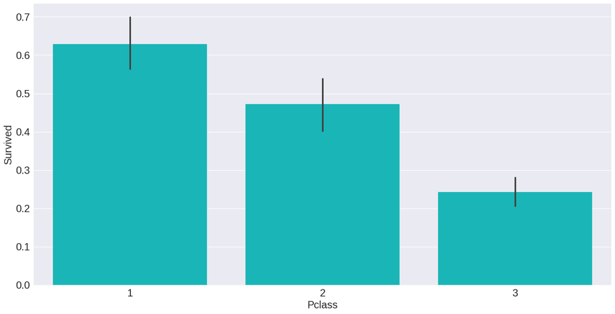

```python
sns.barplot('Pclass', 'Survived', data=train_data, color="darkturquoise")
plt.show()
```

Unsurprisingly, being a first class passenger was safest.[as the ticket price was higher -> the better chance to survive]

## 3.4 Exploration of Embarked Port

```
Boarded passengers grouped by port of embarkation (C = Cherbourg, Q = Queenstown, S = Southampton):
S    644
C    168
Q     77
Name: Embarked, dtype: int64
```

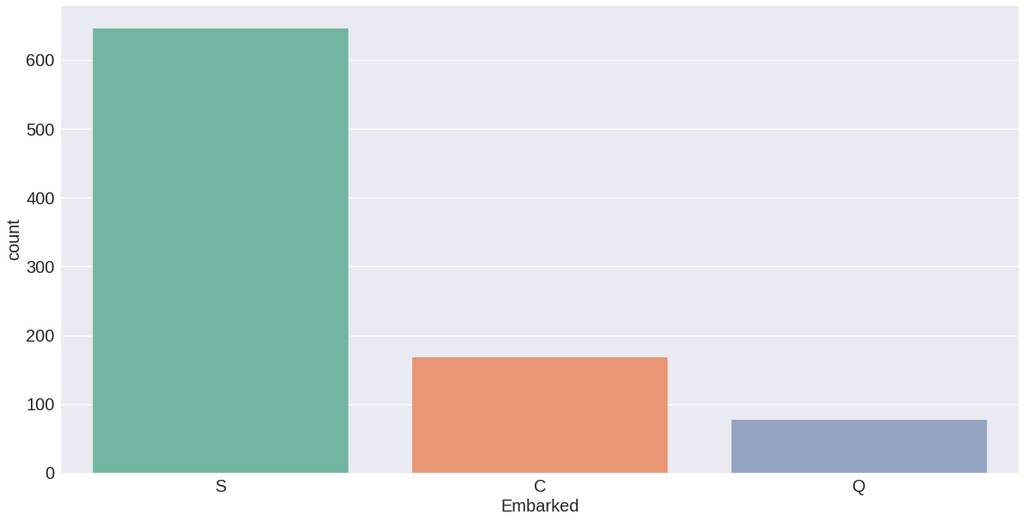

```python
print('Boarded passengers grouped by port of embarkation (C = Cherbourg, Q = Queenstown, S = Southampton):')
print(titanic_df['Embarked'].value_counts())
sns.countplot(x='Embarked', data=train_data, palette='Set2', color="teal")
plt.show()
```

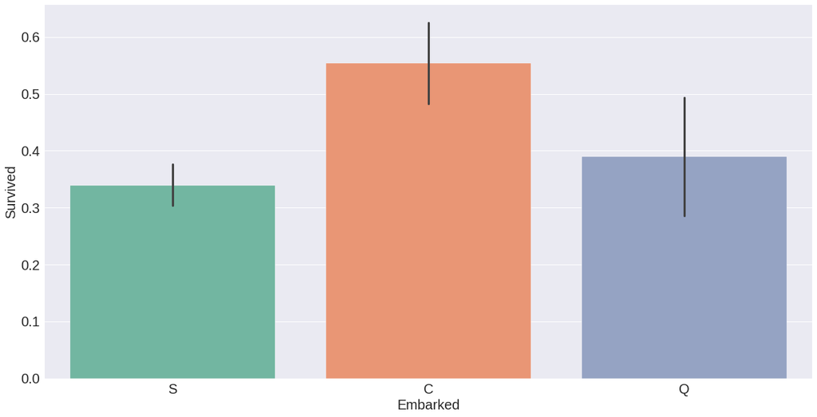

```python
sns.barplot('Embarked', 'Survived', data=train_data, palette='Set2', color="teal")
plt.show()
```

Passengers who boarded in Cherbourg, France, appear to have the highest survival rate. Passengers who boarded in Southhampton were marginally less likely to survive than those who boarded in Queenstown. This is probably related to passenger class, or maybe even the order of room assignments (e.g. maybe earlier passengers were more likely to have rooms closer to deck).  
It's also worth noting the size of the whiskers in these plots. Because the number of passengers who boarded at Southhampton was highest, the confidence around the survival rate is the highest. The whisker of the Queenstown plot includes the Southhampton average, as well as the lower bound of its whisker. It's possible that Queenstown passengers were equally, or even more, ill-fated than their Southhampton counterparts.

## 3.5. Exploration of Traveling Alone vs. With Family

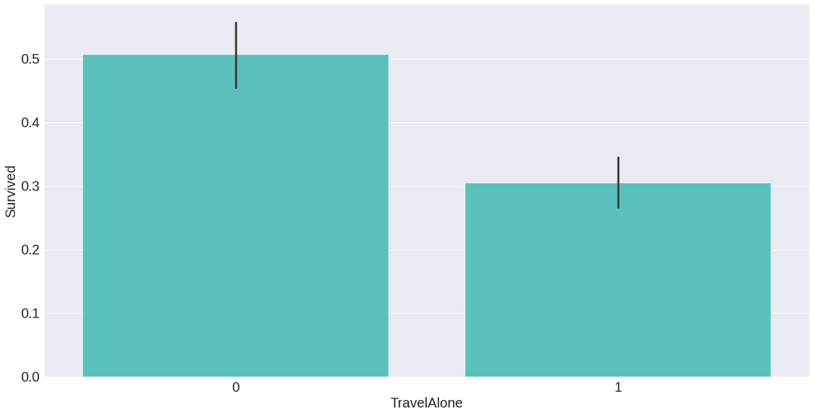

```python
sns.barplot('TravelAlone', 'Survived', data=train_data, color="mediumturquoise")
plt.show()
```

Individuals traveling without family were more likely to die in the disaster than those with family aboard. Given the era, it's likely that individuals traveling alone were likely male.

## 3.6. Exploration of Gender Variable

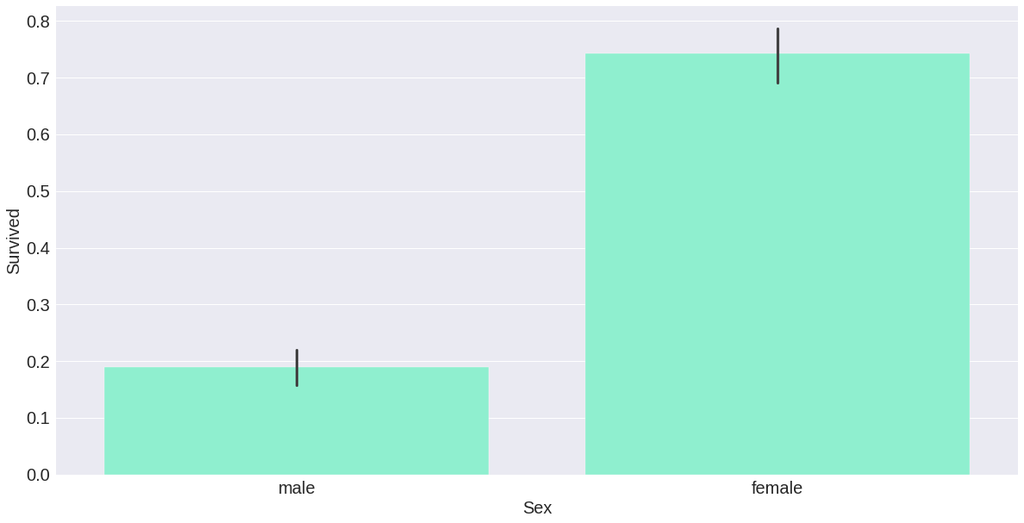

```python
sns.barplot('Sex', 'Survived', data=train_data, color="aquamarine")
plt.show()
```

We see that females have musch higher survavial rates

# 4. Logistic Regression and Results

```python
final_train.head()
```

|  | Survived | Age | Fare | TravelAlone | Pclass_1 | Pclass_2 | Pclass_3 | Embarked_C | Embarked_Q | Embarked_S | Sex_male | IsMinor |
| --- | --- | --- | --- | --- | --- | --- | --- | --- | --- | --- | --- | --- |
| 0 | 0 | 22.0 | 7.2500 | 0 | 0 | 0 | 1 | 0 | 0 | 1 | 1 | 0 |
| 1 | 1 | 38.0 | 71.2833 | 0 | 1 | 0 | 0 | 1 | 0 | 0 | 0 | 0 |
| 2 | 1 | 26.0 | 7.9250 | 1 | 0 | 0 | 1 | 0 | 0 | 1 | 0 | 0 |
| 3 | 1 | 35.0 | 53.1000 | 0 | 1 | 0 | 0 | 0 | 0 | 1 | 0 | 0 |
| 4 | 0 | 35.0 | 8.0500 | 1 | 0 | 0 | 1 | 0 | 0 | 1 | 1 | 0 |

## 4.1. Feature selection

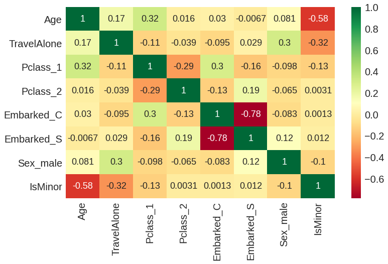

```python
Selected_features = ['Age', 'TravelAlone', 'Pclass_1', 'Pclass_2', 'Embarked_C',
                     'Embarked_S', 'Sex_male', 'IsMinor']
X = final_train[Selected_features]

plt.subplots(figsize=(12, 7))
sns.heatmap(X.corr(), annot=True, cmap="RdYlGn")
plt.show()
```

## 4.2. Model evaluation based on simple train/test split using `train_test_split()` function

```
Train/Test split results:
LogisticRegression accuracy is 0.782
LogisticRegression log_loss is 0.504
LogisticRegression auc is 0.838
```

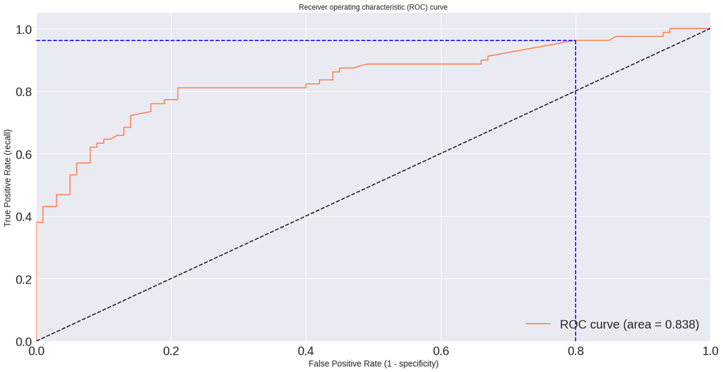

```
Using a threshold of 0.070 guarantees a sensitivity of 0.962 and a specificity of 0.200, i.e. a false positive rate of 80.00%.
```

```python
from sklearn.model_selection import train_test_split, cross_val_score
from sklearn.metrics import accuracy_score, classification_report, precision_score, recall_score
from sklearn.metrics import confusion_matrix, precision_recall_curve, roc_curve, auc, log_loss

# create X (features) and y (response)
X = final_train[Selected_features]
y = final_train['Survived']

# use train/test split with different random_state values
# we can change the random_state values that changes the accuracy scores
# the scores change a lot, this is why testing scores is a high-variance estimate
X_train, X_test, y_train, y_test = train_test_split(X, y, test_size=0.2, random_state=2)

# check classification scores of logistic regression
logreg = LogisticRegression()
logreg.fit(X_train, y_train)
y_pred = logreg.predict(X_test)
y_pred_proba = logreg.predict_proba(X_test)[:, 1]
[fpr, tpr, thr] = roc_curve(y_test, y_pred_proba)
print('Train/Test split results:')
print(logreg.__class__.__name__+" accuracy is %2.3f" % accuracy_score(y_test, y_pred))
print(logreg.__class__.__name__+" log_loss is %2.3f" % log_loss(y_test, y_pred_proba))
print(logreg.__class__.__name__+" auc is %2.3f" % auc(fpr, tpr))

idx = np.min(np.where(tpr > 0.95)) # index of the first threshold for which the sensibility > 0.95

plt.figure()
plt.plot(fpr, tpr, color='coral', label='ROC curve (area = %0.3f)' % auc(fpr, tpr))
plt.plot([0, 1], [0, 1], 'k--')
plt.plot([0,fpr[idx]], [tpr[idx],tpr[idx]], 'k--', color='blue')
plt.plot([fpr[idx],fpr[idx]], [0,tpr[idx]], 'k--', color='blue')
plt.xlim([0.0, 1.0])
plt.ylim([0.0, 1.05])
plt.xlabel('False Positive Rate (1 - specificity)', fontsize=14)
plt.ylabel('True Positive Rate (recall)', fontsize=14)
plt.title('Receiver operating characteristic (ROC) curve')
plt.legend(loc="lower right")
plt.show()

print("Using a threshold of %.3f " % thr[idx] + "guarantees a sensitivity of %.3f " % tpr[idx] +
      "and a specificity of %.3f" % (1-fpr[idx]) +
      ", i.e. a false positive rate of %.2f%%." % (np.array(fpr[idx])*100))
```

```python
# tried to improve model by normlizing the Age and Fair, not succecfully..

# from sklearn.model_selection import train_test_split, cross_val_score
# from sklearn.metrics import accuracy_score, classification_report, precision_score, recall_score
# from sklearn.metrics import confusion_matrix, precision_recall_curve, roc_curve, auc, log_loss

# # create X (features) and y (response)
# X = final_train[Selected_features]
# y = final_train['Survived']

# # use train/test split with different random_state values
# # we can change the random_state values that changes the accuracy scores
# # the scores change a lot, this is why testing scores is a high-variance estimate
# X_train, X_test, y_train, y_test = train_test_split(X, y, test_size=0.2, random_state=2)




# from sklearn.preprocessing import StandardScaler
# sc = StandardScaler()
# X_train[:, :] = sc.fit_transform(X_train[:, :]) # Normlize age and far
# X_test[:, 0:2] = sc.transform(X_test[:, 0:2])


# # check classification scores of logistic regression
# logreg2 = LogisticRegression()
# logreg2.fit(X_train, y_train)
# y_pred = logreg2.predict(X_test)
# y_pred_proba = logreg2.predict_proba(X_test)[:, 1]
# [fpr, tpr, thr] = roc_curve(y_test, y_pred_proba)
# print('Train/Test split results:')
# print(logreg2.__class__.__name__+" accuracy is %2.3f" % accuracy_score(y_test, y_pred))
# print(logreg2.__class__.__name__+" log_loss is %2.3f" % log_loss(y_test, y_pred_proba))
# print(logreg2.__class__.__name__+" auc is %2.3f" % auc(fpr, tpr))

# idx = np.min(np.where(tpr > 0.95)) # index of the first threshold for which the sensibility > 0.95

# plt.figure()
# plt.plot(fpr, tpr, color='coral', label='ROC curve (area = %0.3f)' % auc(fpr, tpr))
# plt.plot([0, 1], [0, 1], 'k--')
# plt.plot([0,fpr[idx]], [tpr[idx],tpr[idx]], 'k--', color='blue')
# plt.plot([fpr[idx],fpr[idx]], [0,tpr[idx]], 'k--', color='blue')
# plt.xlim([0.0, 1.0])
# plt.ylim([0.0, 1.05])
# plt.xlabel('False Positive Rate (1 - specificity)', fontsize=14)
# plt.ylabel('True Positive Rate (recall)', fontsize=14)
# plt.title('Receiver operating characteristic (ROC) curve')
# plt.legend(loc="lower right")
# plt.show()

# print("Using a threshold of %.3f " % thr[idx] + "guarantees a sensitivity of %.3f " % tpr[idx] +
#       "and a specificity of %.3f" % (1-fpr[idx]) +
#       ", i.e. a false positive rate of %.2f%%." % (np.array(fpr[idx])*100))
```

```python
final_test['Survived'] = logreg.predict(final_test[Selected_features])
final_test['PassengerId'] = test_df['PassengerId']

submission = final_test[['PassengerId','Survived']]

submission.to_csv("submission.csv", index=False)

submission.tail()
```

|  | PassengerId | Survived |
| --- | --- | --- |
| 413 | 1305 | 0 |
| 414 | 1306 | 1 |
| 415 | 1307 | 0 |
| 416 | 1308 | 0 |
| 417 | 1309 | 0 |

# To conclude:

We saw strong correlations to survivial rates throught

1. Sex, woman had 3 times more chance to survive,
2. individuals traveling alone were less likly to survive
3. under-age had a good chance to survive
4. Boarding City had some noticable effect on the odds..

### Submission's Score:

[figure not shown]

### Placement in leader board:

[figure not shown]

references :

1. https://www.kaggle.com/omarelgabry/a-journey-through-titanic
2. https://www.kaggle.com/mnassrib/titanic-logistic-regression-with-python
3. https://www.kaggle.com/sgus1318/titanic-analysis-learning-to-swim-with-python

data Pre-Processing:

1. https://colab.research.google.com/drive/1IoB2vtVDt6aulFvLM41o_j-KtdC3drJO#scrollTo=5hwuVddlSwVi

```python
%%shell
jupyter nbconvert --to html /content/ml_2021a_1regression.ipynb
```

```python
%% shell
jupyter nbconvert --to html /content/ml_2021a_1regression (1).ipynb
```